# EASYVISA

### **EDA Insights**

- In addition to the analysis above on the ratio of approved to denied applications by education, previous job experience, continent, prevailing wage, and unit of wage:
- If a job does or does not require training does not affect this ratio.
- If a job is a full-time position or not does not affect this ratio.
- If a job is located in the Midwest or South region, applicants have a higher ratio of approvals than those in the Northeast, West, and particularly the Island region.
- Jobs that applicants with doctorate degree are applying for jobs have the lowest mean prevailing wage of any education.
- Temporary (i.e., not full-time) jobs that applicants are applying for have a significantly higher prevailing wage than full-time positions.
- The ratio of visa applications being certified vs denied increases as the applicant's level of education increases.
- Applicants from Asia comprise ~2/3 of all applications and these applicants have almost a 2:1 ratio of approvals to denials.
- Applicants with job experience have a ratio of approved to denied applications of ~3:1, whereas the same ratio for applicants without job experience is ~1:1.
- Applicants who are applying to work in a job with an hourly rate have a ratio of approved versus denied applications of ~1:2.
- The ratio of approved to denied applications does not increase as the prevailing wage increases.
- If a job is located in the Midwest or South region, applicants have a higher ratio of approvals than those in the Northeast, West, and particularly the Island region.
- Jobs that applicants with doctorate degrees are applying for have the lowest mean prevailing wage of any education.

## **Data Preprocessing**

**Outlier detection**

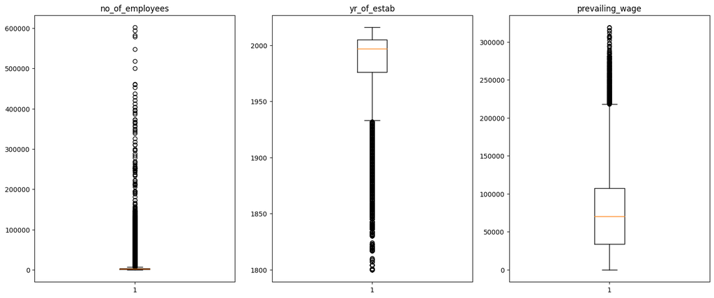

```python
numeric_column = df.select_dtypes(include = np.number)
numeric_column.columns.to_list()

plt.figure(figsize=(20,30))

for i , variable in enumerate (numeric_column):
    plt.subplot(5, 4, i + 1)
    plt.boxplot(data[variable], whis=1.5)
    plt.tight_layout()
    plt.title(variable)

plt.show()
```

- - We can not drop any of the data due to outliers as this will affect our model building.

```python
X = df.drop("case_status", axis = 1)
y = df["case_status"]
```

```python
X = pd.get_dummies(X, drop_first = True)
```

```python
X.shape
```

```
(25480, 21)
```

```python
X.replace(True, 1, inplace = True)
X.replace(False, 0, inplace = True)
```

```python
X.info()
```

```
<class 'pandas.core.frame.DataFrame'>
RangeIndex: 25480 entries, 0 to 25479
Data columns (total 21 columns):
 #   Column                             Non-Null Count  Dtype
---  ------                             --------------  -----
 0   no_of_employees                    25480 non-null  int64
 1   yr_of_estab                        25480 non-null  int64
 2   prevailing_wage                    25480 non-null  float64
 3   continent_Asia                     25480 non-null  int64
 4   continent_Europe                   25480 non-null  int64
 5   continent_North America            25480 non-null  int64
 6   continent_Oceania                  25480 non-null  int64
 7   continent_South America            25480 non-null  int64
 8   education_of_employee_Doctorate    25480 non-null  int64
 9   education_of_employee_High School  25480 non-null  int64
 10  education_of_employee_Master's     25480 non-null  int64
 11  has_job_experience_Y               25480 non-null  int64
 12  requires_job_training_Y            25480 non-null  int64
 13  region_of_employment_Midwest       25480 non-null  int64
 14  region_of_employment_Northeast     25480 non-null  int64
 15  region_of_employment_South         25480 non-null  int64
 16  region_of_employment_West          25480 non-null  int64
 17  unit_of_wage_Month                 25480 non-null  int64
 18  unit_of_wage_Week                  25480 non-null  int64
 19  unit_of_wage_Year                  25480 non-null  int64
 20  full_time_position_Y               25480 non-null  int64
dtypes: float64(1), int64(20)
memory usage: 4.1 MB
```

```python
X_train, X_test, y_train, y_test = train_test_split(X, y, test_size = 0.30, random_state = 101)
```

```python
#confirm the split
print("{0:0.2f}% data is in training set".format((len(X_train)/len(df.index)) * 100))
print("{0:0.2f}% data is in test set".format((len(X_test)/len(df.index)) * 100))
```

```
70.00% data is in training set
30.00% data is in test set
```

```python
#confirm the shape of both data sets and the ratio of classes is the same across both train and test datasets
print("Shape of Training set : ", X_train.shape)
print("Shape of test set : ", X_test.shape)
print(' ')
print("Percentage of classes in training set:")
print(y_train.value_counts(normalize=True))
print(' ')
print("Percentage of classes in test set:")
print(y_test.value_counts(normalize=True))
```

```
Shape of Training set :  (17836, 21)
Shape of test set :  (7644, 21)

Percentage of classes in training set:
case_status
Certified    0.669937
Denied       0.330063
Name: proportion, dtype: float64

Percentage of classes in test set:
case_status
Certified    0.663134
Denied       0.336866
Name: proportion, dtype: float64
```

## **Model Building**

```python
def model_score(model,X_test, y_test):
    '''
    model_score : extract performed model score in single code snippet

    '''
    y_pred = model.predict(X_test)
    acc = accuracy_score(y_test, y_pred)

    cm = metrics.confusion_matrix(y_test, y_pred)

    true_positive = cm[0][0]
    false_positive = cm[0][1]
    false_negative = cm[1][0]
    true_negative = cm[1][1]

    Precision = true_positive/(true_positive+false_positive)

    Recall = true_positive/(true_positive+false_negative)

    F1_Score = 2*(Recall * Precision) / (Recall + Precision)

    print("Confusion Matrix: ", cm)
    print("Accuracy Score: ", acc)
    print("Precision Score: ", Precision)
    print("Recall Score: ", Recall)
    print("F1 Score: ", F1_Score)
```

### **Decision Tree**

```python
dtree = DecisionTreeClassifier()
dtree.fit(X_train,y_train)
```

```
DecisionTreeClassifier()
```

```python
print(dtree.score(X_train,y_train))
print(dtree.score(X_test,y_test))
```

```
1.0
0.6572475143903715
```

```python
model_score(dtree, X_test, y_test)
```

```
Confusion Matrix:  [[3750 1319]
 [1301 1274]]
Accuracy Score:  0.6572475143903715
Precision Score:  0.7397908857762873
Recall Score:  0.7424272421302712
F1 Score:  0.7411067193675889
```

#### **Model Tuning**

```python
# we are tuning some hyperparameters right now, we are passing the different values for both parameters

grid_param = {
    'criterion': ['gini', 'entropy', 'log_loss'],
    'max_depth' : range(2,32,1),
    'min_samples_leaf' : range(1,10,1),
    'min_samples_split': range(2,10,1),
    'splitter' : ['best', 'random']

}
```

```python
grid_search_dtree = GridSearchCV(estimator = dtree,
                     param_grid = grid_param,
                     cv = 5,
                    n_jobs = -1)
```

```python
grid_search_dtree.fit(X_train, y_train)
```

```
GridSearchCV(cv=5, estimator=DecisionTreeClassifier(), n_jobs=-1,
             param_grid={'criterion': ['gini', 'entropy', 'log_loss'],
                         'max_depth': range(2, 32),
                         'min_samples_leaf': range(1, 10),
                         'min_samples_split': range(2, 10),
                         'splitter': ['best', 'random']})
```

```python
best_parameter = grid_search_dtree.best_params_
print(best_parameter)
```

```
{'criterion': 'gini', 'max_depth': 8, 'min_samples_leaf': 2, 'min_samples_split': 9, 'splitter': 'random'}
```

```python
grid_search_dtree.best_score_
```

```
0.7471969479823143
```

```python
dtree_tuned = DecisionTreeClassifier(criterion = 'gini', max_depth = 8, min_samples_leaf = 2, min_samples_split = 9, splitter = 'random')
dtree_tuned.fit(X_train,y_train)
```

```
DecisionTreeClassifier(max_depth=8, min_samples_leaf=2, min_samples_split=9,
                       splitter='random')
```

```python
model_score(dtree_tuned, X_test, y_test)
```

```
Confusion Matrix:  [[4422  647]
 [1297 1278]]
Accuracy Score:  0.7456828885400314
Precision Score:  0.872361412507398
Recall Score:  0.7732121000174855
F1 Score:  0.8197997775305895
```

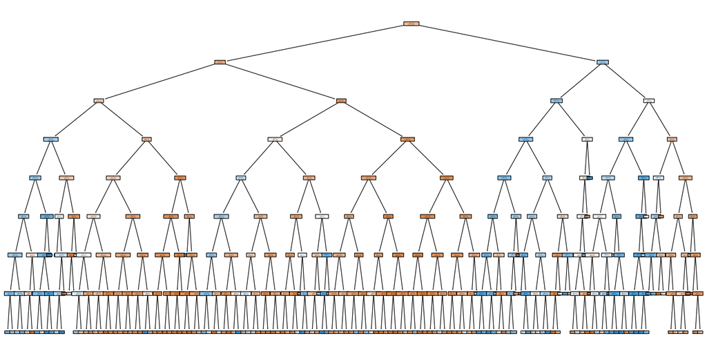

```python
#Visualize the best decision tree

plt.figure(figsize=(20,10))
tree.plot_tree(dtree_tuned, feature_names = X.columns, filled=True,
              class_names = ['Denied', 'Certified'], rounded = True)
plt.show()
```

### **Bagging**

```python
bagging = BaggingClassifier(base_estimator = dtree_tuned , n_estimators = 50, random_state = 1)
bagging.fit(X_train,y_train)
```

```
BaggingClassifier(base_estimator=DecisionTreeClassifier(max_depth=8,
                                                        min_samples_leaf=2,
                                                        min_samples_split=9,
                                                        splitter='random'),
                  n_estimators=50, random_state=1)
```

```python
print(bagging.score(X_train,y_train))
print(bagging.score(X_test,y_test))
```

```
0.7562794348508635
0.7473835688121402
```

```python
model_score(bagging, X_test, y_test)
```

```
Confusion Matrix:  [[4425  644]
 [1287 1288]]
Accuracy Score:  0.7473835688121402
Precision Score:  0.8729532452160189
Recall Score:  0.7746848739495799
F1 Score:  0.8208886003153696
```

#### **Model Tuning**

```python
bagging_tuned1 = BaggingClassifier(base_estimator = 'deprecated' , n_estimators = 20, random_state = 11, max_samples = 10, bootstrap = True)
bagging_tuned1.fit(X_train, y_train)
```

```
BaggingClassifier(max_samples=10, n_estimators=20, random_state=11)
```

```python
print(bagging_tuned1.score(X_train,y_train))
print(bagging_tuned1.score(X_test,y_test))
```

```
0.6758802422067728
0.6700680272108843
```

```python
model_score(bagging_tuned1, X_test, y_test)
```

```
Confusion Matrix:  [[4988   81]
 [2441  134]]
Accuracy Score:  0.6700680272108843
Precision Score:  0.9840205168672322
Recall Score:  0.6714228025306233
F1 Score:  0.7982077132341175
```

```python
bagging_tuned2 = BaggingClassifier(base_estimator = dtree_tuned , n_estimators = 20, random_state = 11, max_samples = 25, bootstrap = False)
bagging_tuned2.fit(X_train, y_train)
```

```
BaggingClassifier(base_estimator=DecisionTreeClassifier(max_depth=8,
                                                        min_samples_leaf=2,
                                                        min_samples_split=9,
                                                        splitter='random'),
                  bootstrap=False, max_samples=25, n_estimators=20,
                  random_state=11)
```

```python
print(bagging_tuned2.score(X_train,y_train))
print(bagging_tuned2.score(X_test,y_test))
```

```
0.706997084548105
0.706436420722135
```

```python
model_score(bagging_tuned2, X_test, y_test)
```

```
Confusion Matrix:  [[4846  223]
 [2021  554]]
Accuracy Score:  0.706436420722135
Precision Score:  0.9560071019925035
Recall Score:  0.7056938983544488
F1 Score:  0.8119973190348526
```

### **Boosting**

#### **AdaBoost**

```python
adaboost = AdaBoostClassifier(n_estimators=10, random_state=1)
adaboost.fit(X_train,y_train)
```

```
AdaBoostClassifier(n_estimators=10, random_state=1)
```

```python
print(adaboost.score(X_train,y_train))
print(adaboost.score(X_test,y_test))
```

```
0.7410293787844808
0.739534275248561
```

```python
model_score(adaboost, X_test, y_test)
```

```
Confusion Matrix:  [[4431  638]
 [1353 1222]]
Accuracy Score:  0.739534275248561
Precision Score:  0.874136910633261
Recall Score:  0.7660788381742739
F1 Score:  0.8165484197917626
```

#### **Model Tuning**

```python
# we are tuning some hyperparameters right now, we are passing the different values for both parameters

grid_param = {
    'n_estimators' : range(2,7,1),
    'base_estimator' : ['dtree_tuned', 'deprecated']
}
```

```python
grid_search_adaboost = GridSearchCV(estimator = adaboost,
                     param_grid = grid_param,
                     cv = 5,
                    n_jobs = -1)
```

```python
grid_search_adaboost.fit(X_train, y_train)
```

```
GridSearchCV(cv=5,
             estimator=AdaBoostClassifier(n_estimators=10, random_state=1),
             n_jobs=-1,
             param_grid={'base_estimator': ['dtree_tuned', 'deprecated'],
                         'n_estimators': range(2, 7)})
```

```python
best_parameter = grid_search_adaboost.best_params_
print(best_parameter)
```

```
{'base_estimator': 'deprecated', 'n_estimators': 5}
```

```python
grid_search_adaboost.best_score_
```

```
0.7271247490385837
```

```python
adaboost_tuned = AdaBoostClassifier()
adaboost_tuned.fit(X_train,y_train)
```

```
AdaBoostClassifier()
```

```python
model_score(adaboost_tuned, X_test, y_test)
```

```
Confusion Matrix:  [[4507  562]
 [1464 1111]]
Accuracy Score:  0.7349555206698064
Precision Score:  0.8891300059183271
Recall Score:  0.7548149388712109
F1 Score:  0.8164855072463768
```

#### **GradientBoost**

```python
Gradientboost = GradientBoostingClassifier(n_estimators=50, random_state=1)
Gradientboost.fit(X_train,y_train)
```

```
GradientBoostingClassifier(n_estimators=50, random_state=1)
```

```python
print(Gradientboost.score(X_train,y_train))
print(Gradientboost.score(X_test,y_test))
```

```
0.7526911863646557
0.748953427524856
```

```python
model_score(Gradientboost, X_test, y_test)
```

```
Confusion Matrix:  [[4462  607]
 [1312 1263]]
Accuracy Score:  0.748953427524856
Precision Score:  0.8802525152890116
Recall Score:  0.772774506408036
F1 Score:  0.8230194595591626
```

#### **Model Tuning**

```python
Gradientboost_tuned1 = GradientBoostingClassifier(criterion = 'friedman_mse', n_estimators=50, random_state=1, max_depth = 5, min_samples_leaf = 5, min_samples_split = 4)
Gradientboost_tuned1.fit(X_train,y_train)
```

```
GradientBoostingClassifier(max_depth=5, min_samples_leaf=5, min_samples_split=4,
                           n_estimators=50, random_state=1)
```

```python
print(Gradientboost_tuned1.score(X_train,y_train))
print(Gradientboost_tuned1.score(X_test,y_test))
```

```
0.7665395828661135
0.749345892203035
```

```python
model_score(Gradientboost_tuned1, X_test, y_test)
```

```
Confusion Matrix:  [[4418  651]
 [1265 1310]]
Accuracy Score:  0.749345892203035
Precision Score:  0.8715723022292365
Recall Score:  0.7774062994897062
F1 Score:  0.8218005952380953
```

```python
Gradientboost_tuned2 = GradientBoostingClassifier(criterion = 'squared_error', n_estimators=70, random_state=5, max_depth = 10, min_samples_leaf = 10, min_samples_split = 6)
Gradientboost_tuned2.fit(X_train,y_train)
```

```
GradientBoostingClassifier(criterion='squared_error', max_depth=10,
                           min_samples_leaf=10, min_samples_split=6,
                           n_estimators=70, random_state=5)
```

```python
print(Gradientboost_tuned2.score(X_train,y_train))
print(Gradientboost_tuned2.score(X_test,y_test))
```

```
0.8467705763624132
0.7343014128728415
```

```python
model_score(Gradientboost_tuned2, X_test, y_test)
```

```
Confusion Matrix:  [[4394  675]
 [1356 1219]]
Accuracy Score:  0.7343014128728415
Precision Score:  0.8668376405602684
Recall Score:  0.7641739130434783
F1 Score:  0.8122747019133008
```